# Statistical inference with the GSS data

## Setup

### Load packages

```r
library(ggplot2)
library(dplyr)
library(statsr)
library(magrittr)
library(MASS)
```

### Load data

```r
load(url("http://bit.ly/dasi_gss_data"))
test_gss = dplyr::select(gss, attend, consci) %>% na.omit()
test_gss$attend <- droplevels(test_gss$attend)
levels(test_gss$attend)
```

```
## [1] "Lt Once A Year"   "Once A Year"      "Sevrl Times A Yr"
## [4] "Once A Month"     "2-3X A Month"     "Nrly Every Week"
## [7] "Every Week"       "More Thn Once Wk"
```

We have removed “Never” level in Attend because it has 0 entries.

## Part 1: Data

### Introduction:

The relationship between religion and science has been a subject of study since classical antiquity, addressed by philosophers, theologians, scientists, and others. Perspectives from different geographical regions, cultures and historical epochs are diverse, with some characterizing the relationship as one of conflict, others describing it as one of harmony, and others proposing little interaction. Public acceptance of scientific facts may be influenced by religion; many in the United States reject the idea of evolution by natural selection, especially regarding human beings.

In this paper, we will analyze General Social Survey (GSS) data, particullary religious services attendance and confidence in scientific community variables in order to find out whether there is a statistical relationship between the religious services attendance and the amount of confidence that person has in the scientific community?

1. ATTEND (HOW OFTEN R ATTENDS RELIGIOUS SERVICES) - ordinal variable
2. CONSCI (CONFIDENCE IN SCIENTIFIC COMMUNITY) - ordinal variable

If we omit NA values, we’ll get 29756 cases and 2 variables. Since data comes from survey it’s clear an observational study. Full probability sample was used for most of the surveys, one-half block quota was used in the early years, see Appendix A in ICPSR Codebook for further details. Our population of interest is the whole US population, however the data were collected only from English and Spanish speaking persons 18 years of age or older, living in the United States and thus we can generalize our findings only to that population. Moreover since it is an survey, it may be source of the non-response bias. Since it’s an observational study we can’t establish any causal links.

## Part 2: Research question

Research Question: Is there a statistical relationship between the religious services attendance and the amount of confidence that person has in the scientific community?

## Part 3: Exploratory data analysis

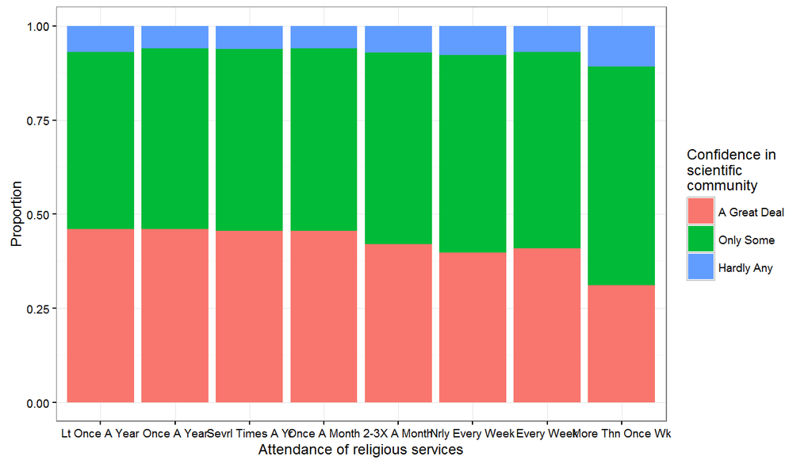

```r
ggplot(test_gss,aes(x = attend,fill = consci)) +
  geom_bar(position = "fill") +
  xlab("Attendance of religious services") +
  ylab("Proportion") +
  labs(fill="Confidence in \nscientific \ncommunity") +
  theme_bw(9)
```

As we can see people who visit religious services more than 2-3 times a month tend to have lower confidence in science.

We can express this difference also in numbers: (we exclude row that responds for Answer “Never” because there is none observed.)

```r
my = with(test_gss,
         table(attend, consci)
)
round( prop.table(my, 1), 2)
```

```
##                   consci
## attend             A Great Deal Only Some Hardly Any
##   Lt Once A Year           0.46      0.47       0.07
##   Once A Year              0.46      0.48       0.06
##   Sevrl Times A Yr         0.46      0.48       0.06
##   Once A Month             0.46      0.48       0.06
##   2-3X A Month             0.42      0.51       0.07
##   Nrly Every Week          0.40      0.52       0.08
##   Every Week               0.41      0.52       0.07
##   More Thn Once Wk         0.31      0.58       0.11
```

## Part 4: Inference

We formulate the null hypothesis and alternative hypothesis: $H_0$: Religious services attendance and Confidence in science are independent. Confidence in science do not vary by Religious service attendance. $H_A$: Religious services attendance and Confidence in science are dependent. Confidence in science do vary by Religious services attendance. Since we have two categorical variables, we would like to do the Chi-square test of independence test, but we must check the conditions first: Since we made random sampling we satisfy the indepencence condition. Our sample (29756) is clearly less than 10% of the US population (~300 mil.) and each case contributes only to one cell in the table (interviewee can have only one frequency of attendance and only one opinion on science).

```r
prop.table(table(test_gss$consci))
```

```
##
## A Great Deal    Only Some   Hardly Any
##   0.42502352   0.50480575   0.07017072
```

```r
table(test_gss$attend)
```

```
##
##   Lt Once A Year      Once A Year Sevrl Times A Yr     Once A Month
##             2789             4791             4603             2598
##     2-3X A Month  Nrly Every Week       Every Week More Thn Once Wk
##             3185             2005             7073             2712
```

We have 2 categorical variables which have R and C levels respectivelly. Then we have R*C scenarios which coresponds to all possible combination of the values. For each scenario we calculate expected counts E. We assume the independence in $H_0$ and in independent variables $p(A and B) = p(A)p(B)$, so we simply multiply two proportions. Then we compare it with observed values O. If they were really independent this should by approximatelly 0. We square the difference because we want positive number plus we want to penalize bigger differences. Then we divide it by E because we want it to be relative squared difference. Finally we sum all the relative squared differences together and we’ll get chi-squared value. For sure chi-squared summed from larger number of cells will be larger so we must take into account degrees of freedom which is `(R-1)(C-1)`. From these two values (chi-squared and df) we’ll get the p-value (using corresponding tables or R), which tells us if we should reject $H_0$ or not.

```r
chisq.test(my)
```

```
##
##  Pearson's Chi-squared test
##
## data:  my
## X-squared = 256.48, df = 14, p-value < 2.2e-16
```

Our p-value is really small which means that we should reject $H_0$ in favour of $H_A$. It means that Religious services attendance and Confidence in science are dependent.

We can now compare groups “Lt Once A Year” vs “More Thn Once Wk” in the very same way. $H_0$: Groups “Lt Once A Year” vs “More Thn Once Wk” have same confidence in science. Religious services attendace and Confidence in science areindependent within these two groups. $H_A$: Groups “Lt Once A Year” vs “More Thn Once Wk” and Confidence in science are dependent within these two groups.

```r
my_sub = subset(test_gss, attend=='Lt Once A Year' | attend=='More Thn Once Wk')
my_sub$attend = factor(my_sub$attend)

prop.table(table(my_sub$consci))
```

```
##
## A Great Deal    Only Some   Hardly Any
##   0.38702054   0.52463189   0.08834757
```

```r
table(my_sub$attend)
```

```
##
##   Lt Once A Year More Thn Once Wk
##             2789             2712
```

```r
my2 = table(my_sub)
chisq.test(my2)
```

```
##
##  Pearson's Chi-squared test
##
## data:  my2
## X-squared = 134.58, df = 2, p-value < 2.2e-16
```

P-value is again very small, which means that we should reject $H_0$, so we can claim that group of people that vist religious services more than once a week have lower Confidence in science compared to group of people that visit religious less than once a year.

Here we should also mention that no other methods than chi-square testing are applicable, so we can’t calculate the confidence interval and compare the result to the results from hypothesis test.

### Conclusion:

Using chi-square test we showed that Confidence to scientific community depends on Religious services attendance, i.e. some groups of people have lower and some higher confidence in scientific community. Particularly we showed that group of peole that visit religious services more than once a week have lower confidence in science than group of people that visit it less than once a year.

In future research we can try to find some confounding variables (e.g. age), however as I already mention we will never be able to establish any causal links.